# Доклад на тему

Сетевые возможности Linux

Исупов О.Д.

Российский университет дружбы народов, Москва, Россия

16 апреля 2024

# Информация

## Докладчик

- Исупов Олег Денисович
- НПИбд-02-23, студ.билет:1132239122
- Российский университет дружбы народов
- [1132239122@pfur.ru]

# Основная часть

## Введение

- В современном мире сетевые технологии играют ключевую роль в обеспечении связности и доступности информации. Операционные системы, особенно Linux, играют важную роль в сетевой инфраструктуре благодаря своей гибкости, мощным инструментам и богатому набору функций.

## Базовые сетевые компоненты Linux

- Linux предоставляет множество инструментов для управления сетевыми интерфейсами, маршрутизацией и настройкой сетевых соединений. Команды ifconfig и ip позволяют администраторам конфигурировать и управлять сетевыми интерфейсами, а также определять маршруты для передачи сетевого трафика.

## Управление сетевыми соединениями

- Для удобного управления сетевыми соединениями в Linux существует ряд инструментов, включая NetworkManager. Этот инструмент позволяет легко настраивать подключения к сети через графический интерфейс или командную строку. Также администраторы могут конфигурировать сеть непосредственно через файлы конфигурации, такие как interfaces и resolv.conf.

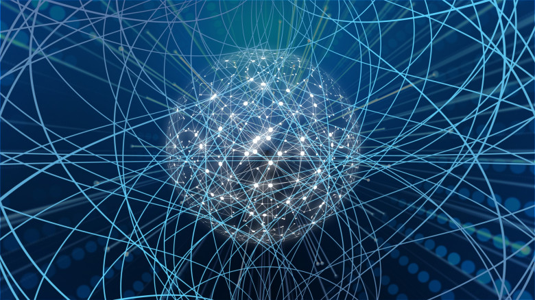

## Инструменты диагностики сети

- Для диагностики сетевых проблем Linux предоставляет широкий набор инструментов, включая ping, traceroute, mtr, а также мощные средства анализа сетевого трафика, такие как tcpdump и Wireshark. Эти инструменты позволяют быстро и эффективно определить и устранить сетевые неполадки.

[figure not shown]

## Безопасность и сетевые возможности Linux

- Важной частью сетевых технологий Linux является обеспечение безопасности сетевых соединений. Linux предоставляет мощные инструменты для фильтрации трафика, такие как iptables и nftables, а также возможности для настройки VPN-соединений и шифрования сетевого трафика с помощью SSL/TLS и SSH.

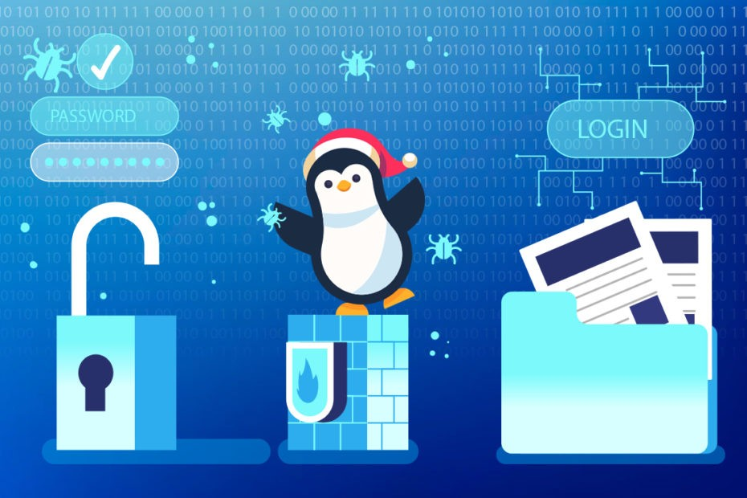

## Новые тенденции в сетевых технологиях Linux

- Современные тенденции в сетевых технологиях Linux включают в себя контейнеризацию и сетевые пространства имен, SDN на основе Linux, а также использование Linux в облачной и виртуализированной среде. Эти новые подходы открывают новые возможности для развертывания и управления сетевой инфраструктурой.

[figure not shown]

## Заключение

- Сетевые возможности Linux играют ключевую роль в современной сетевой инфраструктуре благодаря своей гибкости, надежности и мощным функциональным возможностям. Понимание этих возможностей позволяет администраторам эффективно управлять сетевой инфраструктурой и обеспечивать высокий уровень доступности и безопасности сети.